# Medidas de tendencia central

Gabriell Quetzalli Santana Reyes

2025-09-05

Para analizar el tema del desempleo en México, se cuenta con una base de datos que recopila distintas variables involucradas con el tema y medidas desde el año 2000 hasta el 2016. A continuación se muestran las variables y sus medidas de tendencia central.

## Índice de dependencia por edad (porcentaje de la población en edad de trabajar)

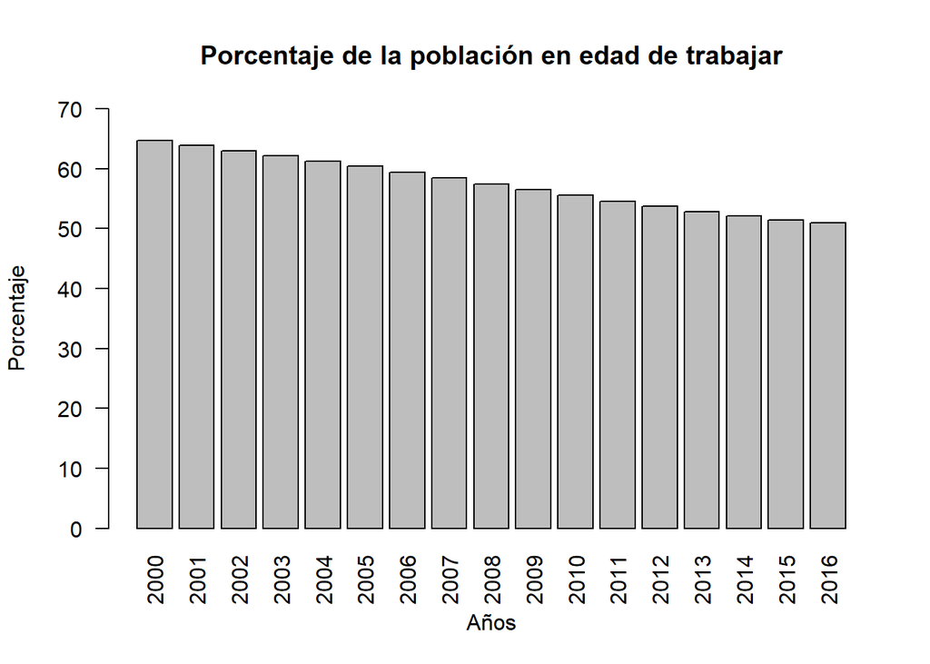

La media es 57.54318%.

La mediana es 57.44503%.

Como todos los datos son distintos, no hay moda.

El rango es 13.8276%.

La varianza es 20.6851%.

La desviación estándar es 4.54808%.

## Empleadores, hombres (% del empleo masculino) (estimación modelada de la OIT)

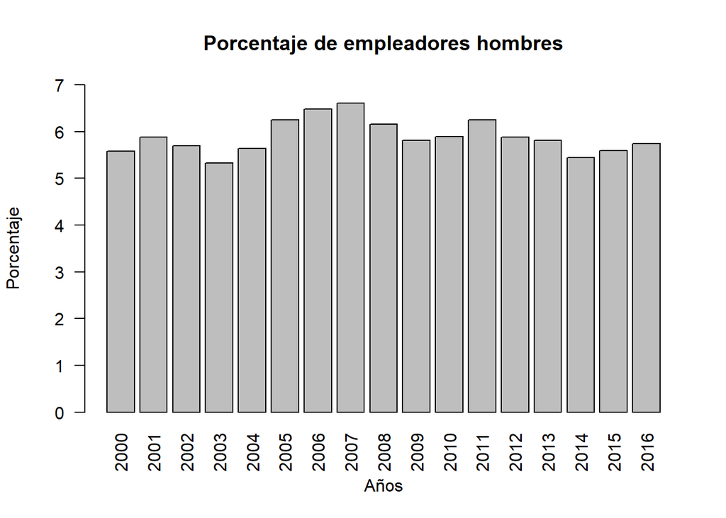

La media es 5.88441%.

La mediana es 5.81599%.

Como todos los datos son distintos, no hay moda.

El rango es 1.27%.

La varianza es 0.12668%.

La desviación estándar es 0.35592%.

## Empleadores, mujeres (% del empleo femenino) (estimación modelada de la OIT)

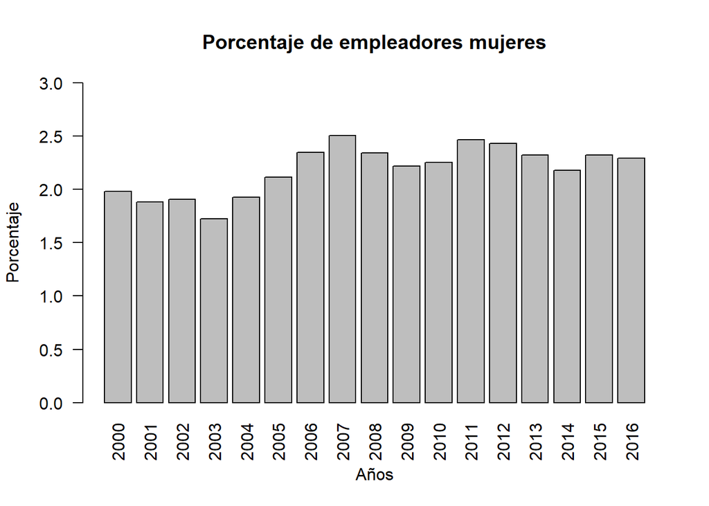

La media es 2.18935%.

La mediana es 2.255%.

Como todos los datos son distintos, no hay moda.

El rango es 0.77799%.

La varianza es 0.05224%.

La desviación estándar es 0.22856%.

## Índice GINI (estimación del Banco Mundial)

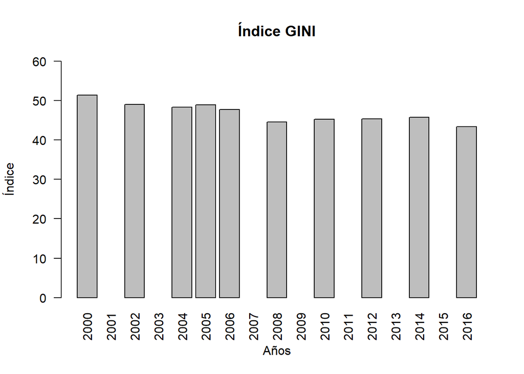

**Nota:** Hay datos faltantes en algunos años.

La media es 46.98.

La mediana es 46.75.

Como todos los datos son distintos, no hay moda.

El rango es 8.

La varianza es 6.084.

La desviación estándar es 2.46657.

## Tasa de participación en la fuerza laboral, mujeres (% de la población femenina de 15+ años) (estimación modelada de la OIT)

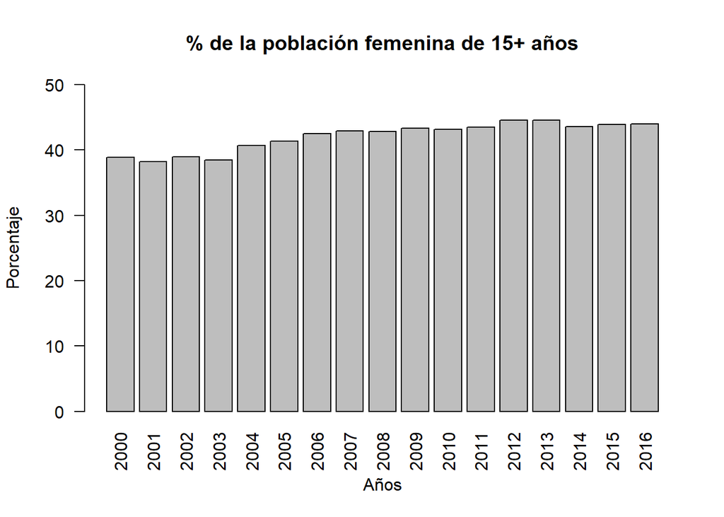

La media es 42.07082%.

La mediana es 42.923%.

Como todos los datos son distintos, no hay moda.

El rango es 6.386%.

La varianza es 4.9258%.

La desviación estándar es 2.2194%.

## Tasa de participación en la fuerza laboral, hombres (% de la población masculina de 15+ años) (estimación modelada de la OIT)

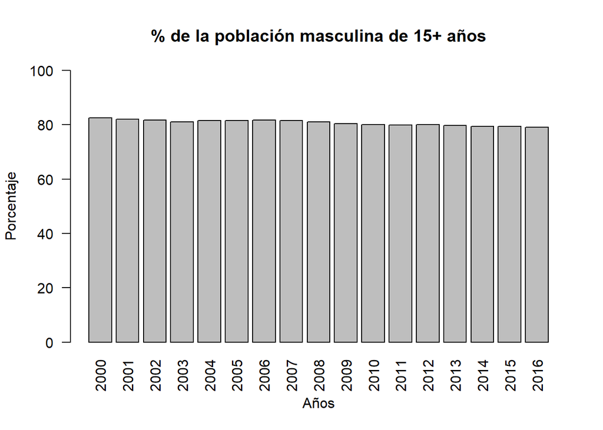

La media es 80.74394%.

La mediana es 81.04699%.

Como todos los datos son distintos, no hay moda.

El rango es 3.479%.

La varianza es 1.12944%.

La desviación estándar es 1.06275%.

## Fuerza laboral, total

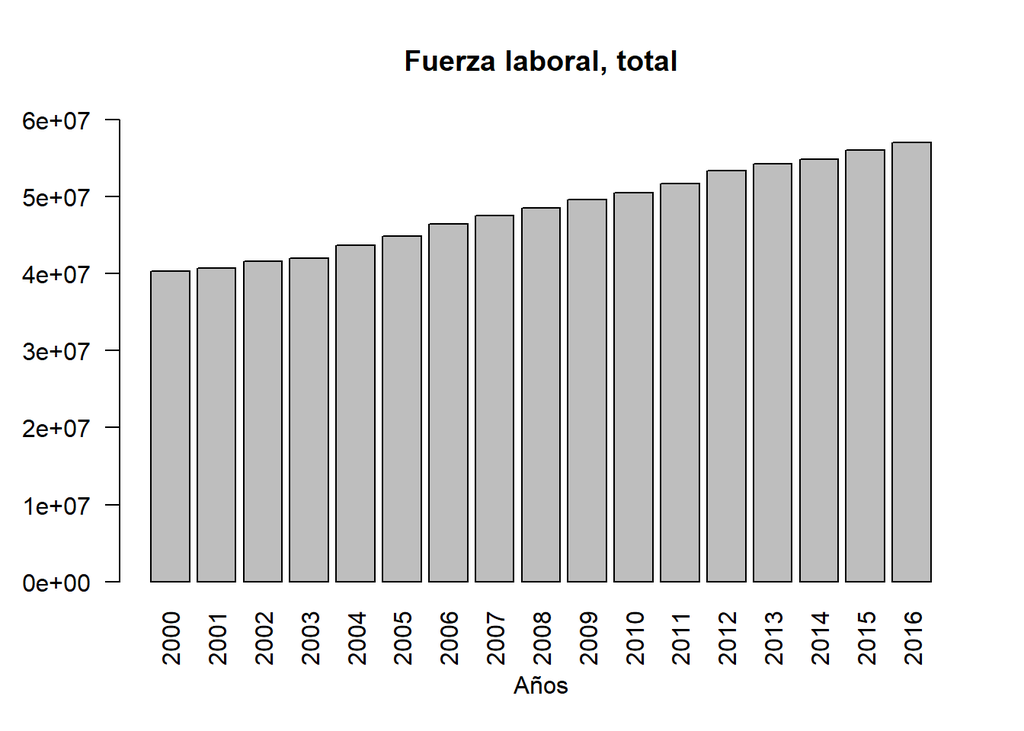

La media es 48407938.

La mediana es 48488143.

Como todos los datos son distintos, no hay moda.

El rango es 16654502.

La varianza es 3.130805e+13.

La desviación estándar es 5595360.

## Trabajadores por cuenta propia, mujeres (% del empleo femenino) (estimación modelada de la OIT

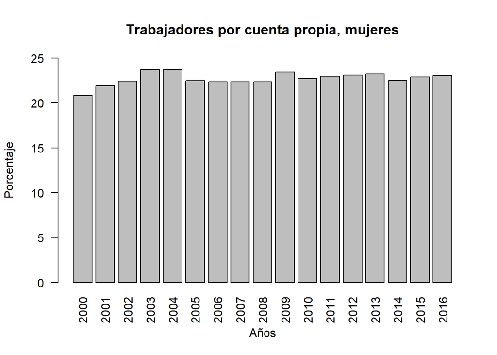

La media es 22.71405%.

La mediana es 22.738%.

Como todos los datos son distintos, no hay moda.

El rango es 2.88299%.

La varianza es 0.49413%.

La desviación estándar es 0.70295%.

## Trabajadores por cuenta propia, hombres (% del empleo masculino) (estimación modelada de la OIT)

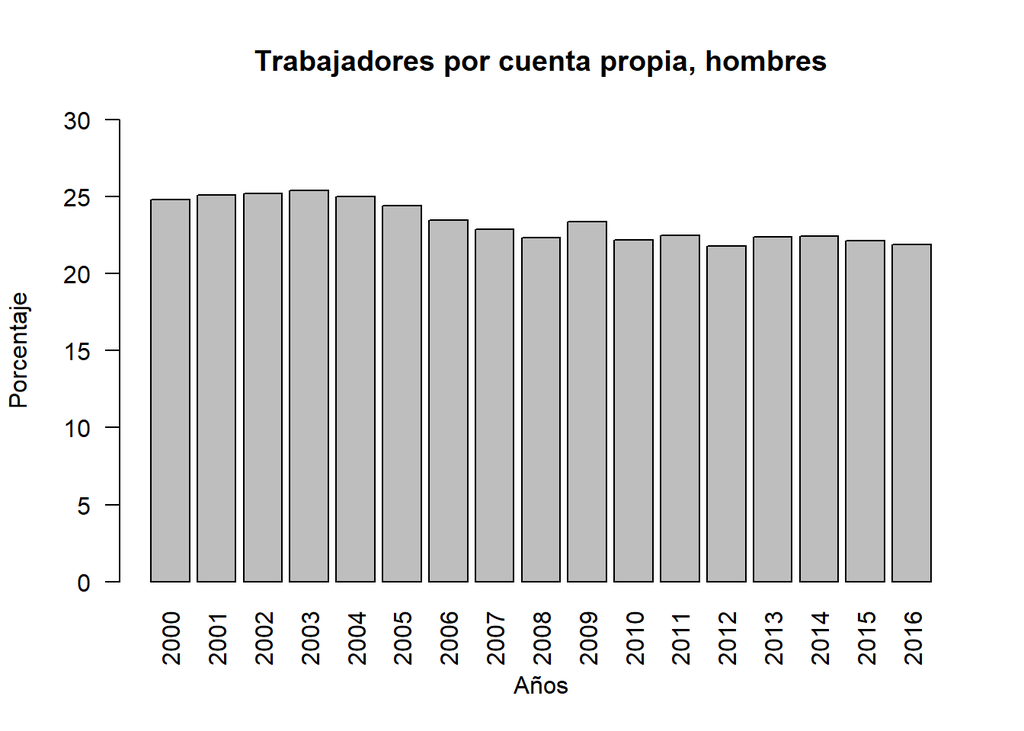

La media es 23.36805%.

La mediana es 22.881%.

Como todos los datos son distintos, no hay moda.

El rango es 3.64399%.

La varianza es 1.74989%.

La desviación estándar es 1.32283%.

## Empleo total, total (15+ años)

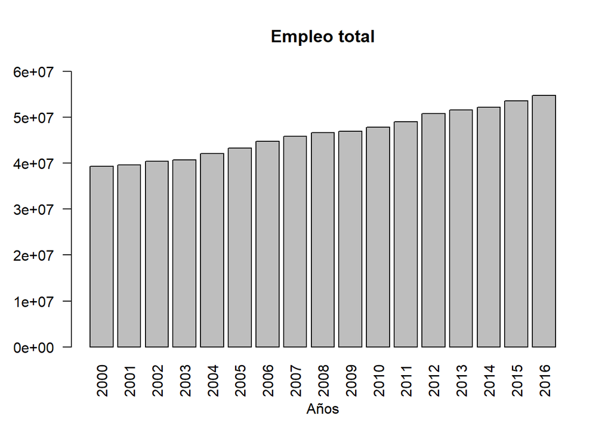

La media es 46430019.

La mediana es 46597412.

Como todos los datos son distintos, no hay moda.

El rango es 15476391%.

La varianza es 25373480605809.

La desviación estándar es 5037209.

## Desempleo con educación avanzada (% de la fuerza laboral total con educación avanzada)

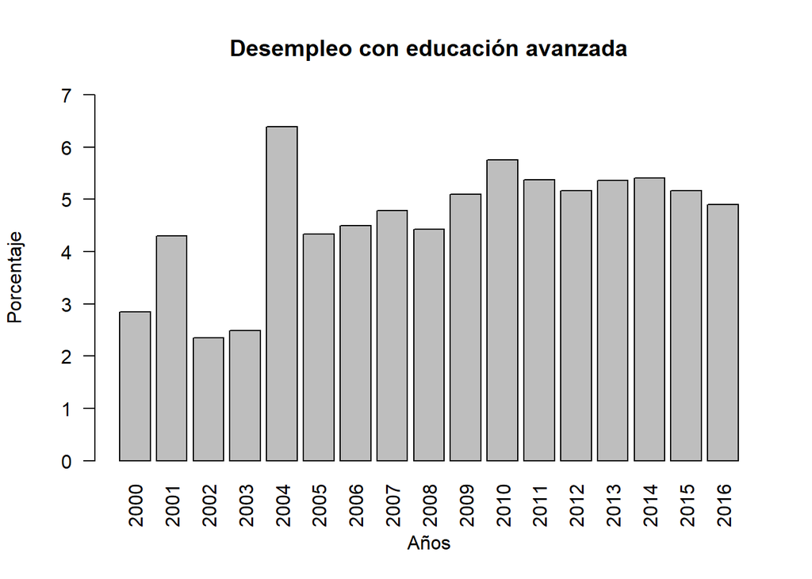

La media es 4.62504%.

La mediana es 4.89799%.

Como todos los datos son distintos, no hay moda.

El rango es 4.03999%.

La varianza es 1.25722%.

La desviación estándar es 1.12126%.

## Desempleo con educación intermedia (% de la fuerza laboral total con educación intermedia)

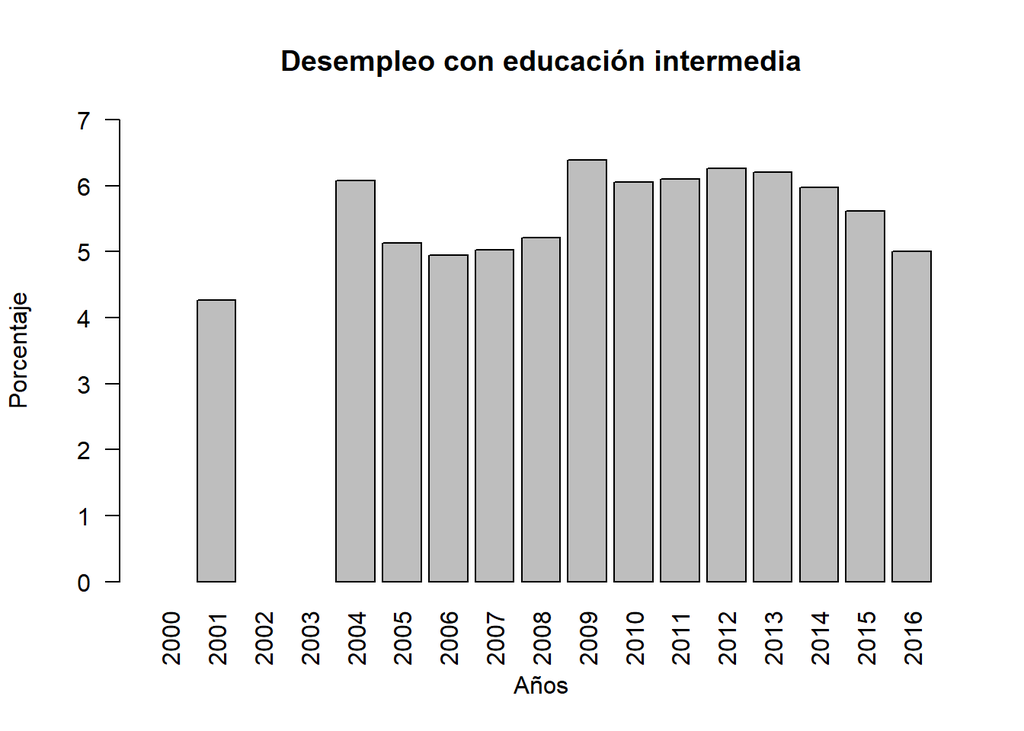

**Nota:** Hay datos faltantes en algunos años.

Como todos los datos son distintos, no hay moda.

El rango es 2.1194%.

La varianza es 0.42329%.

La desviación estándar es 0.65061%.

## Desempleo, jóvenes total (% de la fuerza laboral total de 15-24 años) (estimación modelada de la OIT)

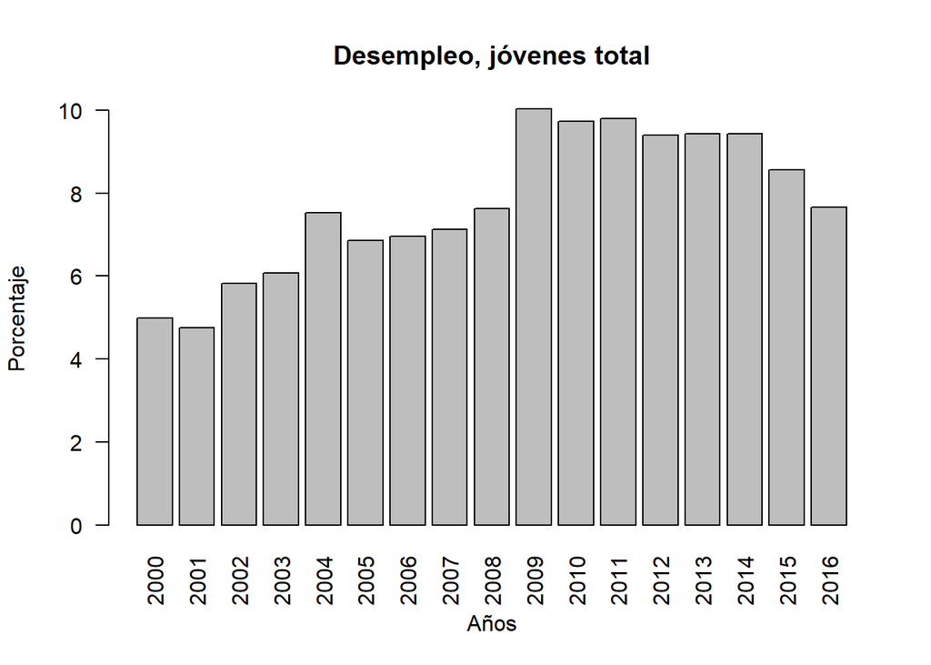

La media es 7.75164%.

La mediana es 7.62099%.

Como todos los datos son distintos, no hay moda.

El rango es 5.27699%.

La varianza es 2.96351%.

La desviación estándar es 1.72148%.